# 82fc3a08-227d-4f5d-97aa-8a0078465ac7

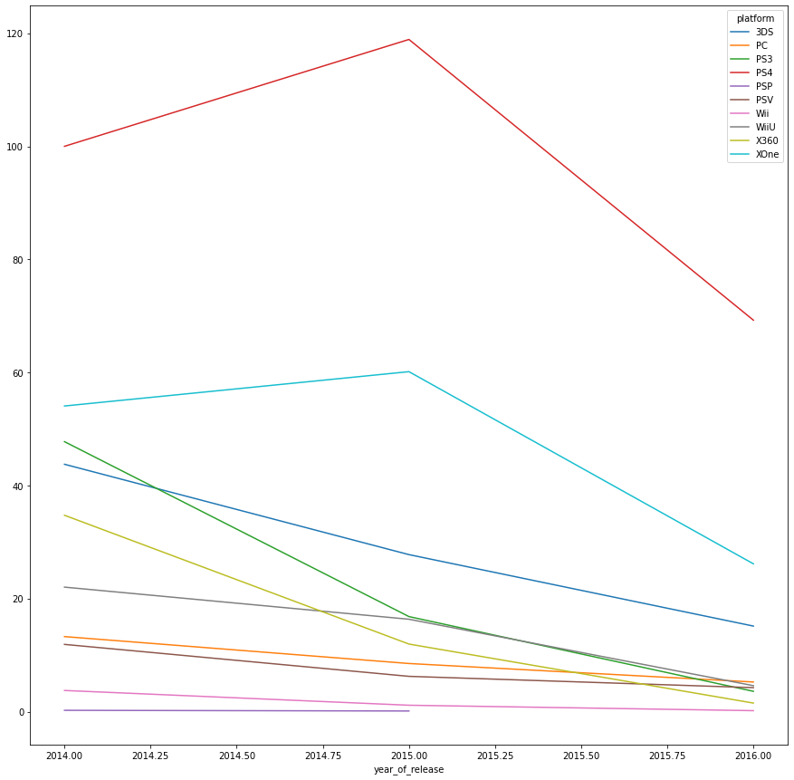

```python
# какие платформы растут или падают. Выберем потенциально прибыльные платформы.
platforms = data.pivot_table(index='year_of_release', columns = 'platform', values='sum_sales', aggfunc='sum')
platforms.plot(figsize=(15, 15))
```

Наблюдаем падение продаж по всем платформам с 2015 года. Платформы PS4 и XOne имеют самые высокие продажи в исследуемом периоде. А у платформы 3DS плавное снижение продаж, но на 2016 год наблюдаем не самое рекордное падение среди остальных платформ, она третяя по продажам.

К потенциально прибыльными платформами я бы отнесла три "верхних": PS4, XOne, 3DS.

А вот с самым минимум продаж на 2016, Wii, X360, PS3 - отнесла бы к потенциально "умирающим" платформам.

```python
data.groupby('platform')['sum_sales'].describe()
```

| platform | count | mean | std | min | 25% | 50% | 75% | max |
| --- | --- | --- | --- | --- | --- | --- | --- | --- |
| 3DS | 212.0 | 0.408868 | 1.188368 | 0.01 | 0.0300 | 0.090 | 0.2500 | 11.68 |
| PC | 151.0 | 0.179139 | 0.329359 | 0.01 | 0.0200 | 0.060 | 0.2000 | 3.05 |
| PS3 | 219.0 | 0.311324 | 0.633059 | 0.01 | 0.0400 | 0.110 | 0.3250 | 5.27 |
| PS4 | 376.0 | 0.766356 | 1.614969 | 0.01 | 0.0575 | 0.185 | 0.6900 | 14.63 |
| PSP | 13.0 | 0.027692 | 0.027735 | 0.01 | 0.0100 | 0.020 | 0.0200 | 0.09 |
| PSV | 295.0 | 0.075932 | 0.141591 | 0.01 | 0.0200 | 0.040 | 0.0900 | 1.96 |
| Wii | 11.0 | 0.460909 | 0.625451 | 0.01 | 0.0350 | 0.180 | 0.7550 | 2.01 |
| WiiU | 73.0 | 0.588767 | 1.161467 | 0.01 | 0.0500 | 0.190 | 0.5700 | 7.09 |
| X360 | 111.0 | 0.434414 | 0.628967 | 0.01 | 0.0700 | 0.180 | 0.5050 | 4.28 |
| XOne | 228.0 | 0.615614 | 1.046513 | 0.01 | 0.0500 | 0.205 | 0.6325 | 7.39 |

```
(0.0, 2.0)
```

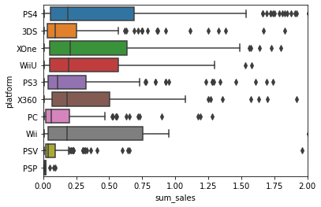

```python
sns.boxplot(data = data, x='sum_sales', y='platform')
plt.xlim([0, 2])
```

На диаграмме размаха мы видим, что у всех платформ имеются выбросы. И правомерно было бы считать, что все продажи свыше 1.5 миллионов аномалии и убрать их из дальнейшего исследования.

```python
data = data[data['sum_sales'] < 1.5]
data.info()
```

```
<class 'pandas.core.frame.DataFrame'>
Int64Index: 1574 entries, 1274 to 16714
Data columns (total 12 columns):
 #   Column           Non-Null Count  Dtype
---  ------           --------------  -----
 0   name             1574 non-null   object
 1   platform         1574 non-null   object
 2   year_of_release  1574 non-null   int64
 3   genre            1574 non-null   object
 4   na_sales         1574 non-null   float64
 5   eu_sales         1574 non-null   float64
 6   jp_sales         1574 non-null   float64
 7   other_sales      1574 non-null   float64
 8   critic_score     639 non-null    float64
 9   user_score       797 non-null    float64
 10  rating           1574 non-null   object
 11  sum_sales        1574 non-null   float64
dtypes: float64(7), int64(1), object(4)
memory usage: 159.9+ KB
```

Как видим, корректировка выбросов составила менее 7% от нашего исследуемого обьема данных. Так мы убедились, что не допустили ошибочно завышенного объема удаления данных.

Рассмотрим вопрос, как влияют на продажи отзывы пользователей и критиков на примере платформы PS4.

```
0.31201948131079993
```

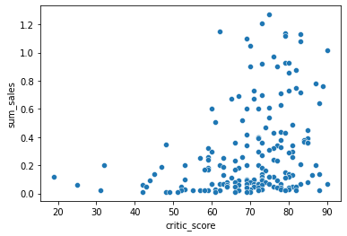

```python
#построим диаграмму рассеяния и посчитаем корреляцию между оценкой критиков и продажами для PS4
plat = data[data['platform']=='PS4']
print(plat['critic_score'].corr(plat['sum_sales']))
sns.scatterplot(x='critic_score', y='sum_sales', data=plat)
```

Корреляция составила 0.312, что характеризует низкую зависимость продаж от оценки критиков.

```
0.034387142185840526
```

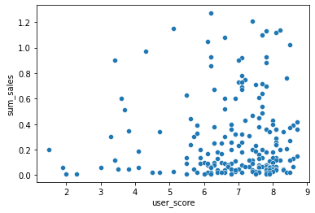

```python
#построим диаграмму рассеяния и посчитаем корреляцию между оценкой пользователей и продажами для PS4
plat = data[data['platform']=='PS4']
print(plat['user_score'].corr(plat['sum_sales']))
sns.scatterplot(x='user_score', y='sum_sales', data=plat)
```